# Numpy

- Numpy is a library in python that is used for scientific computing
- It allows us to use high-performance multidimensional array objects
- In this tutorial we will only go over the very basics of numpy

## Arrays

- A numpy array is a grid of values of the same type

[figure not shown]

Let's take a look:

```python
import numpy as np #np is the standard convention we use for numpy

ra = np.array([1,2,3]) #rank 1 array (1D array)

print(ra)
```

```
[1 2 3]
```

## Array components

Let's evaluate some of the components that allow us to see our array

- **Type:** The type returned will be ndarray which means an n-dimensional array
- **Shape:** The shape will show us a tuple of the dimensions on the array

```python
print(type(ra)) #Shows us the type of array
print(ra.shape) #One dimensional so should only print one dimension
```

```
<class 'numpy.ndarray'>
(3,)
```

## Functions to Create Arrays

We can create arrays quickly using different numpy functions

- **zeros:** Prints out an array of all zeroes with specified dimensions
- **ones:** Prints out array of ones with specified dimensions
- **full:** Prints out array of specified value and of specified dimensions
- **eye:** Prints identity matrix
- **random.random:** Creates array filled with random values of specified dimension

```python
zero_ra = np.zeros((3,2)) #Array of zeroes 3 dimensions 2 elements in each dimension
print("zero array prints out: \n", zero_ra)

ones_ra = np.ones((1,2)) #1 dimension 2 element in dimension
print("ones array prints out: \n", ones_ra)

full_ra = np.full((2,3), 5) #2 dimensions, 3 elements per dimension, filled with 5's
print("full array prints out: \n" , full_ra)

eye_ra = np.eye(2) #2x2 identity matrix
print("eye array prints out: \n", eye_ra)

rand_ra = np.random.random((2,2)) #2 dimensions, 2 elements in dimensions, random values
print("random array prnts out: \n", rand_ra)
```

```
zero array prints out:
 [[0. 0.]
 [0. 0.]
 [0. 0.]]
ones array prints out:
 [[1. 1.]]
full array prints out:
 [[5 5 5]
 [5 5 5]]
eye array prints out:
 [[1. 0.]
 [0. 1.]]
random array prnts out:
 [[0.46378876 0.05957896]
 [0.72465327 0.99598289]]
```

# Matplotlib

- In this tutorial we're going to show you the matplotlib library
- This library will help us visually represent our data
- We will only go over the pyplot module in matplotlib because it is the most used module
- We won't use an actual data set but we're going to be working with numpy arrays

```python
import matplotlib.pyplot as plt #importing pyplot from matplotlib
import numpy as np #Numpy is a package we haven't gone over but we'll include it in this tutorial
```

## Pyplot

- Pyplot is a module of Matplotlib
- It allows us to plot our data into a variety of graphs
- the usual order of creating a graph starts with defining it then using the show function to display it

Let's take a look a make a simple graph:

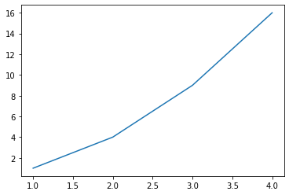

```python
#   plot( x-values,  y-values)
plt.plot([1,2,3,4], [1,4,9,16])
plt.show()
```

## Labeling Graphs

We can specify graph information such as the title, labels, and more

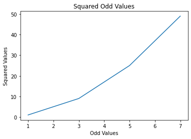

```python
plt.plot([1,3,5,7], [1,9,25,49]) #declare plot
plt.title("Squared Odd Values") #add title
plt.xlabel("Odd Values") #add labels
plt.ylabel("Squared Values")
plt.show() #Show
```

## Plotting Various Data

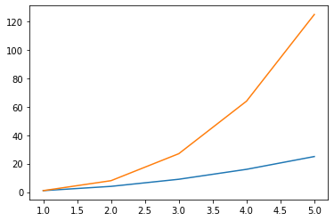

```python
x = np.array([1,2,3,4,5])
y_one = x**2 #to the power of 2
y_two = x**3 #to the power of 3

plt.plot(x, y_one, x, y_two) #Passing two different arguments
plt.show()
```

## Different Graph Types

We're not going too much into the customizability of the graphs but I will show you different types of graphs:

- Bar Chart
- Pie Charts
- Histogram
- Scatter Plots

### Bar Chart

A bar chart is typically used when you want to compare metric values accross different subgroups in your data  
To create a bar chart use the plt.bar function in order to create one

- bar(): The bar function takes a couple of arguments bar(different categories, caterogy values, color='insert color')
- barh(): this bar function displays bar chart horizontally and uses the same arguements

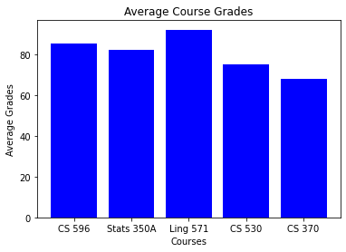

```python
courses = ["CS 596", "Stats 350A", "Ling 571", "CS 530", "CS 370"] #Declare categories
course_average_grades = [85, 82, 92, 75, 68] #Category values

plt.bar(courses, course_average_grades, color='blue') #Provide arguments to create bar chart
plt.title("Average Course Grades") #create labels
plt.xlabel("Courses")
plt.ylabel("Average Grades")
plt.show() #show
```

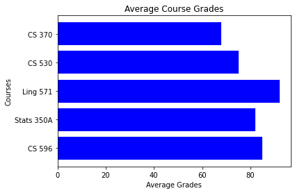

```python
plt.barh(courses, course_average_grades, color='blue') #create chart
plt.title("Average Course Grades") #Add labels
plt.xlabel("Average Grades")
plt.ylabel("Courses")
plt.show() #display
```

### Pie Chart

Used to show percentage of proportionial data

- pie(): the arguements here are simple pie(values, labels=created_values)

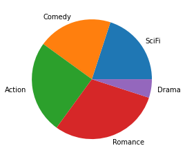

```python
movie_types = ["SciFi", "Comedy", "Action", "Romance", "Drama"] #Creating labels
rankings = [20, 20, 25, 30, 5] #Creating values

plt.pie(rankings, labels=movie_types) #Creating pie chart
plt.show() #Showing
```

### Histogram

This chart is used to plot the frequency of occurrences in a continuous data set divided by bins

- hist(): hist(values) We only need to provide the occurences of values

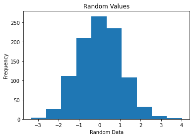

```python
rand_values = np.random.randn(1000) #Different from random.random; this return values larger than 0-1

plt.hist(rand_values) #Create graph
plt.title("Random Values") #Add labels
plt.xlabel("Random Data")
plt.ylabel("Frequency")
plt.show() #display
```

### Scatterplot

plots points for two numeric values in order to observe relationships between variables

- scatter(): scatter(x-values, y_values)

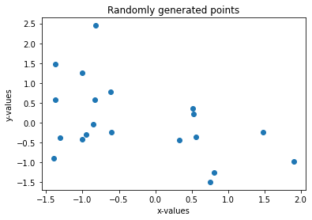

```python
x = np.random.randn(20) #Generate random values
y = np.random.randn(20)

plt.scatter(x,y) #Create scatterplot
plt.title("Randomly generated points") #Add labels
plt.xlabel("x-values")
plt.ylabel("y-values")
plt.show() #display
```

## The Actual potential of matplotlib

Above we showed basic functions in order to plot graphs. However, you can customize graphs a lot more than that, below is a quick showcase of these advanced graphs

```python
import pandas as pd
import numpy
import matplotlib.pyplot as plt
```

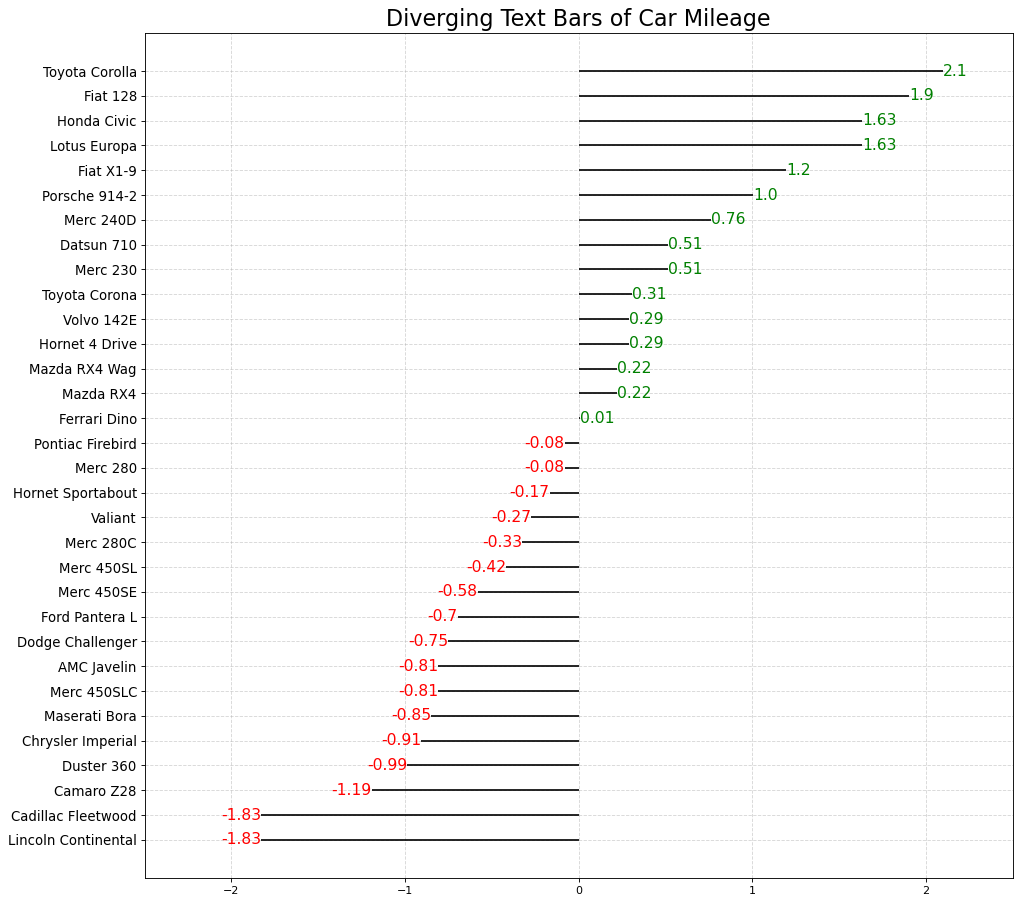

```python
df = pd.read_csv("https://github.com/selva86/datasets/raw/master/mtcars.csv")
x = df.loc[:, ['mpg']]
df['mpg_z'] = (x - x.mean())/x.std()
df['colors'] = ['red' if x < 0 else 'green' for x in df['mpg_z']]
df.sort_values('mpg_z', inplace=True)
df.reset_index(inplace=True)

# Draw plot
plt.figure(figsize=(14,14), dpi= 80)
plt.hlines(y=df.index, xmin=0, xmax=df.mpg_z)
for x, y, tex in zip(df.mpg_z, df.index, df.mpg_z):
    t = plt.text(x, y, round(tex, 2), horizontalalignment='right' if x < 0 else 'left',
                 verticalalignment='center', fontdict={'color':'red' if x < 0 else 'green', 'size':14})

# Decorations
plt.yticks(df.index, df.cars, fontsize=12)
plt.title('Diverging Text Bars of Car Mileage', fontdict={'size':20})
plt.grid(linestyle='--', alpha=0.5)
plt.xlim(-2.5, 2.5)
plt.show()
```

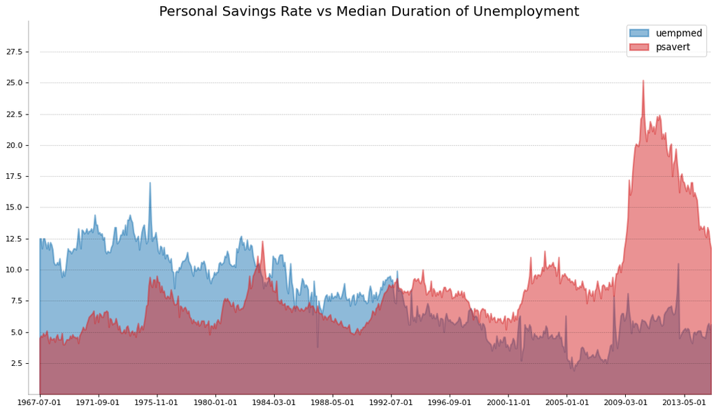

```python
df = pd.read_csv("https://github.com/selva86/datasets/raw/master/economics.csv")

# Prepare Data
x = df['date'].values.tolist()
y1 = df['psavert'].values.tolist()
y2 = df['uempmed'].values.tolist()
mycolors = ['tab:red', 'tab:blue', 'tab:green', 'tab:orange', 'tab:brown', 'tab:grey', 'tab:pink', 'tab:olive']
columns = ['psavert', 'uempmed']

# Draw Plot
fig, ax = plt.subplots(1, 1, figsize=(16,9), dpi= 80)
ax.fill_between(x, y1=y1, y2=0, label=columns[1], alpha=0.5, color=mycolors[1], linewidth=2)
ax.fill_between(x, y1=y2, y2=0, label=columns[0], alpha=0.5, color=mycolors[0], linewidth=2)

# Decorations
ax.set_title('Personal Savings Rate vs Median Duration of Unemployment', fontsize=18)
ax.set(ylim=[0, 30])
ax.legend(loc='best', fontsize=12)
plt.xticks(x[::50], fontsize=10, horizontalalignment='center')
plt.yticks(np.arange(2.5, 30.0, 2.5), fontsize=10)
plt.xlim(-10, x[-1])

# Draw Tick lines
for y in np.arange(2.5, 30.0, 2.5):
    plt.hlines(y, xmin=0, xmax=len(x), colors='black', alpha=0.3, linestyles="--", lw=0.5)

# Lighten borders
plt.gca().spines["top"].set_alpha(0)
plt.gca().spines["bottom"].set_alpha(.3)
plt.gca().spines["right"].set_alpha(0)
plt.gca().spines["left"].set_alpha(.3)
plt.show()
```

Thanks to the following sites for the resources used to create this tutorial:  
[numpy](https://towardsdatascience.com/numpy-array-cookbook-generating-and-manipulating-arrays-in-python-2195c3988b09)  
[numpy](https://cs231n.github.io/python-numpy-tutorial/)  
[matplotlib](https://towardsdatascience.com/matplotlib-tutorial-learn-basics-of-pythons-powerful-plotting-library-b5d1b8f67596)  
[matplotlib graphs](https://www.machinelearningplus.com/plots/top-50-matplotlib-visualizations-the-master-plots-python/)